# HW2 Analysis of NO2 data Key

# Grading

This was a more open-ended homework. Grading was 3/5 if you made a solid attempt at questions 1-8 but didn’t do anything extra (extra plots, more analysis, tables, discussion of what is going on). 4/5 if you did some of the optional questions. 5/5 if you did 4+ optional or additional analyses or delved deeper into questions 1-8.

## The data and packages

```r
load("ECNNO2.RData")
```

Load the packages.

```r
library(MARSS)
library(ggplot2)
library(ggmap)
library(tidyr)
library(dplyr)
```

These are the site locations and names. Note that the site numbers do not indicate how close the sites are to each other.

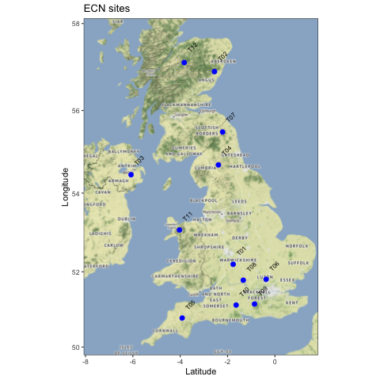

There are 23 years of monthly data for each site and at each site there are 1-3 samples (tubes) taken.

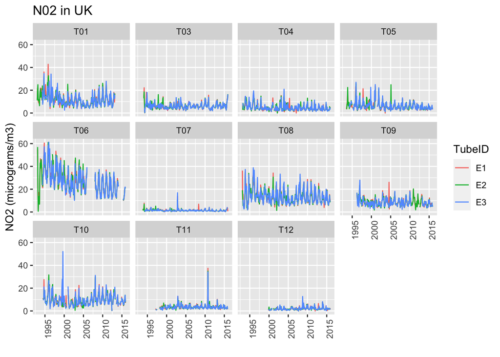

The winter NO$_2$ is higher and more variable than summer (coal plants?). You’ll focus on the winter average data for the first part of the homework and the monthly data for the second part of the homework.

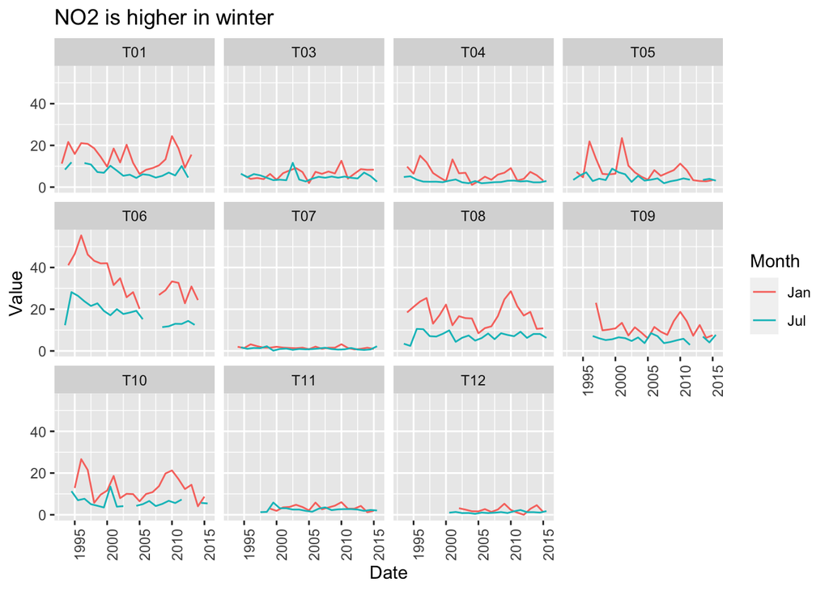

# Part 1

## Data for part 1

```r
dat = ECNNO2 %>%
  subset(Month %in% c("Nov", "Dec", "Jan")) %>%
  subset(TubeID=="E1") %>%
  group_by(Year, SiteCode, TubeID) %>%
  summarize(log.mean = log(mean(Value, na.rm=TRUE)))
# replace NaN with NA
dat[is.na(dat)] <- as.numeric(NA)
```

Make this into a matrix.

```r
datwide <- pivot_wider(
    dat,
    names_from = Year,
    values_from = log.mean
  )
# make into a matrix
datmat <- as.matrix(datwide[,3:23])
rownames(datmat) <- datwide$SiteCode
```

## Questions for part 1

1. Fit a stochastic level (random walk with drift) to estimate one regional NO$_2$ trend from the 11 observations. So 1 $x$ and 11 $y$. All $y$ are observing the same $x$. You will need to set Z and R. You can leave everything else at the default values. So your MARSS() call will look like

```r
mod.list1 <- list(Z = matrix(1, 11, 1),
                     R = "diagonal and unequal")
fit1 <- MARSS(datmat, model=mod.list1)
```

This model has an AICc value of 27.5528735.

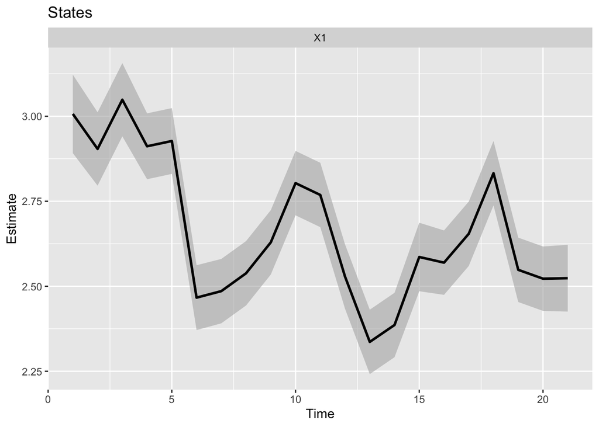

```r
autoplot(fit1, plot.type = "xtT")
```

2. What structure(s) did you assume for the $\mathbf{R}$ matrix (the observation variance covariance matrix)? What do the different structures mean in terms of how the observation errors are related across sites.
- `R="diagonal and equal"` The observation errors independent with equal variance.
- R=“diagonal and unequal” The observation errors independent with different variances.
- R=“unconstrained” The observation errors can be correlated and have different variance and covariances.
- R=“equalvarcov” The observation errors can be correlated with equal variance and one covariance.

We can fit each and see which is most supported.

```r
Z <- matrix(1, 11, 1)
fit1b <- MARSS(datmat, model=list(Z=Z, R="diagonal and equal"))
fit1c <- MARSS(datmat, model=list(Z=Z, R="unconstrained"))
fit1d <- MARSS(datmat, model=list(Z=Z, R="equalvarcov"))
```

And then look at the table.

```r
df <- data.frame(
  R=c("diagonal and unequal","diagonal and equal",
      "unconstrained", "equalvarcov"),
  AICc=c(fit1$AICc, fit1b$AICc, fit1c$AICc, fit1d$AICc)
)
knitr::kable(df)
```

| R | AICc |
| --- | --- |
| diagonal and unequal | 27.55287 |
| diagonal and equal | 62.23435 |
| unconstrained | 131.39249 |
| equalvarcov | 64.53942 |

3. Do basic diagnostics (ACF, normality tests) on the innovations residuals. Any obvious problems?

Not too bad but T03 especially seems to have a trend issue (residuals are not temporally stationary). T11 has some outliers.

```r
resids <- residuals(fit1)
```

You can use `plot(fit1)` and get some basic residuals plots but let’s make them ourselves.

### Plot the residuals

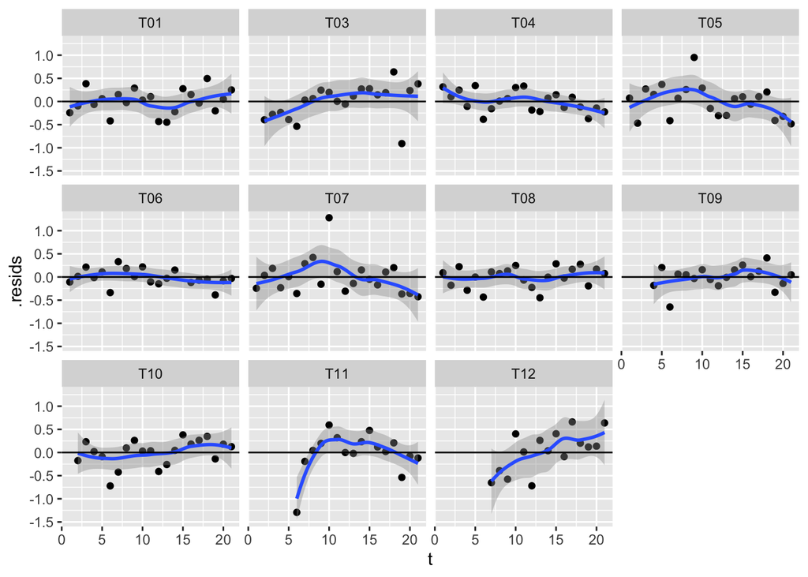

```r
ggplot(resids, aes(x=t, y=.resids)) + geom_point() +
  stat_smooth() + geom_hline(yintercept=0) +
  facet_wrap(~.rownames)
```

### Plot the histograms

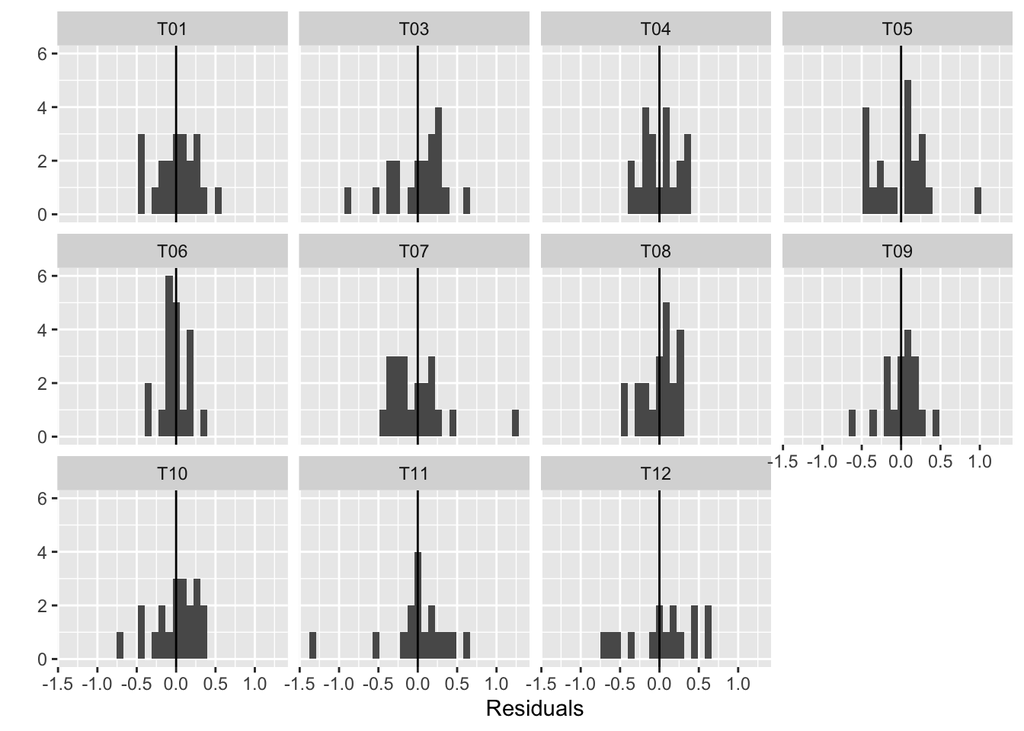

```r
ggplot(resids, aes(x=.resids)) +
  geom_histogram() +
  facet_wrap(~.rownames) +
  ylab("") + xlab("Residuals") +
  geom_vline(xintercept = 0)
```

### Plot QQ plots

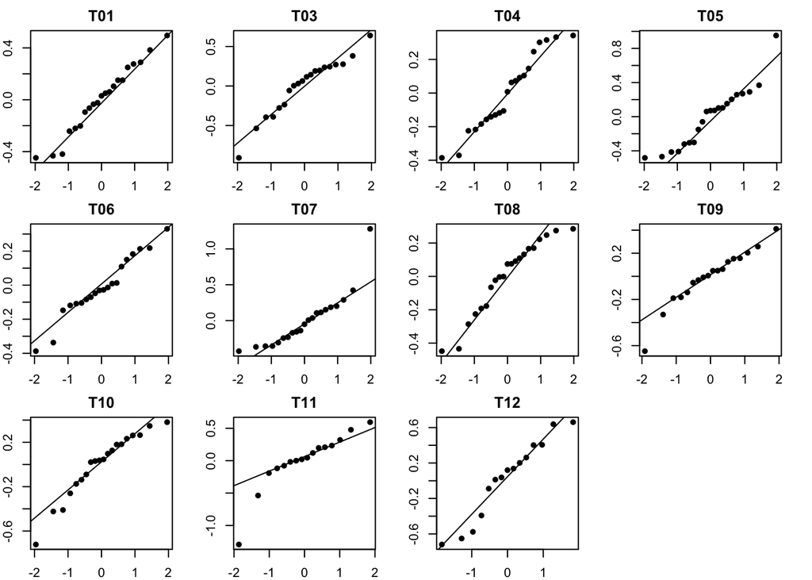

```r
par(mfrow = c(3,4), mar=c(2,2,2,2))
sites <- rownames(datmat)
for(i in sites){
  tmp <- subset(resids, .rownames==i)$.resids
  qqnorm(tmp, main = i, pch =16, xpd = NA, xlab="", ylab="")
  qqline(tmp)
}
```

### Plot ACFs

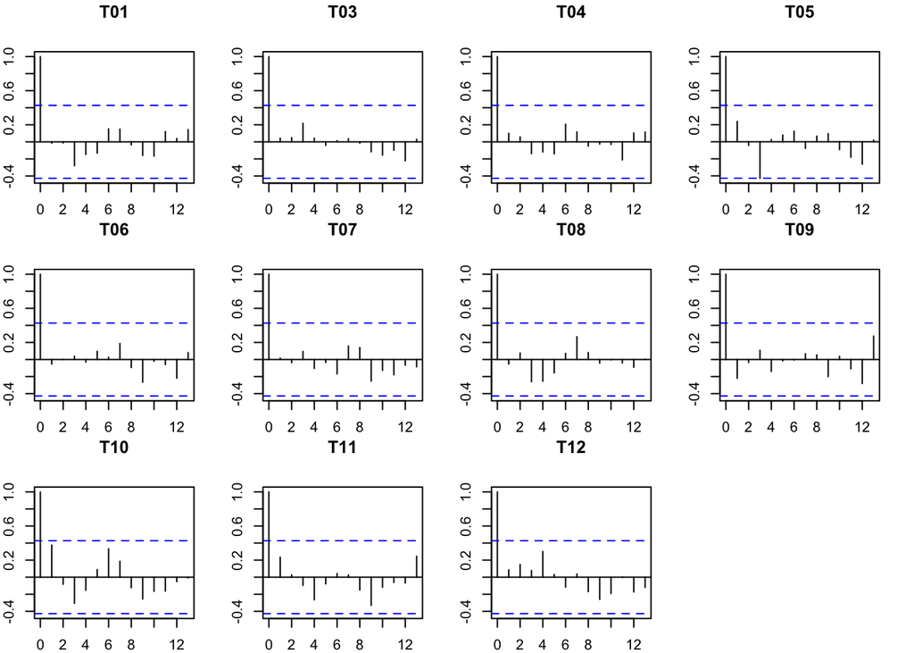

```r
par(mfrow = c(3,4), mar=c(2,2,3,2))
sites <- rownames(datmat)
for(i in sites){
  tmp <- subset(resids, .rownames==i)$.resids
  acf(tmp, na.action=na.pass, main=i)
}
```

### Residuals versus Fitted

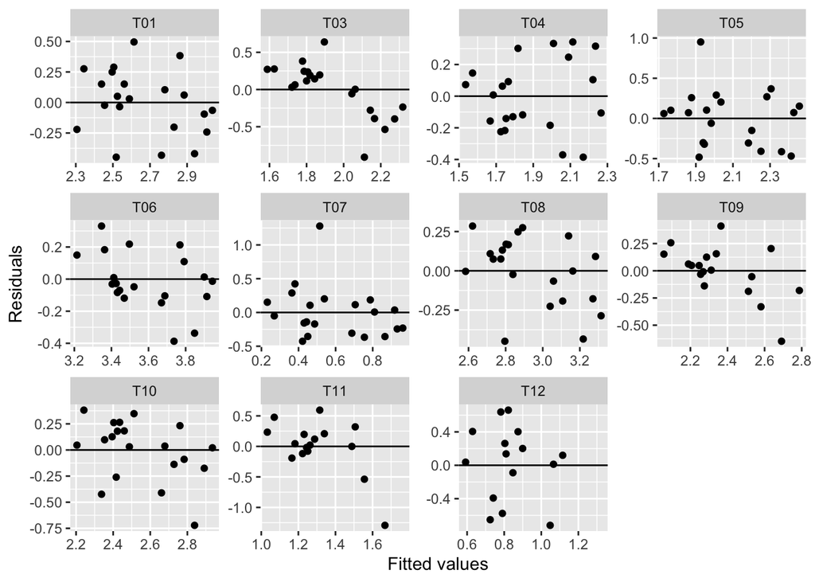

```r
ggplot(resids, aes(x = .fitted, y = .resids)) + geom_point() +
  facet_wrap(~ .rownames, scales = "free") + xlab("Fitted values") + ylab("Residuals") +
  geom_hline(yintercept=0)
```

4. Model the data as 3 regions, each with its own NO$_2$ trend. Those are the states or $x$.
- Region 1 = T01, T05, T06, T08, T09, T10
- Region 2 = T04, T07, T12
- Region 3 = T03, T11

The key here is setting up the $\mathbf{Z}$ matrix (0s and 1s) and then making that in R.

The $\mathbf{Z}$ will look like

$$\mathbf{Z} =
\begin{matrix}
T01 \\
T03 \\
T04 \\
T05 \\
T06 \\
T07 \\
T08 \\
T09 \\
T10 \\
T11 \\
T12
\end{matrix}
\begin{bmatrix}
1&0&0 \\
0&0&1 \\
0&1&0 \\
1&0&0 \\
1&0&0 \\
0&1&0 \\
1&0&0 \\
1&0&0 \\
1&0&0 \\
0&0&1 \\
0&1&0
\end{bmatrix}$$

```r
Z <- matrix(0, 11, 3)
Z[c(1,4,5,7,8,9),1] <- 1
Z[c(3, 6, 11),2] <- 1
Z[c(2, 10),3] <- 1
```

We have to decide what to assume about $\mathbf{Q}$. Let’s start with independent with different variances.

```r
mod.list2 <- list(Z = Z,
                     R = "diagonal and unequal")
fit2 <- MARSS(datmat, model=mod.list2)
```

The AICc for this model is quite a bit larger: 48.671774.

Let’s try an unconstrained $\mathbf{Q}$.

```r
mod.list3 <- list(Z = Z,
                  R = "diagonal and unequal",
                  Q = "unconstrained")
fit3 <- MARSS(datmat, model=mod.list3)
```

The AICc for this model is smaller 25.3222632.

If we look at the $\mathbf{Q}$ variance-covariance matrix we can see why the independent assumption was bad.

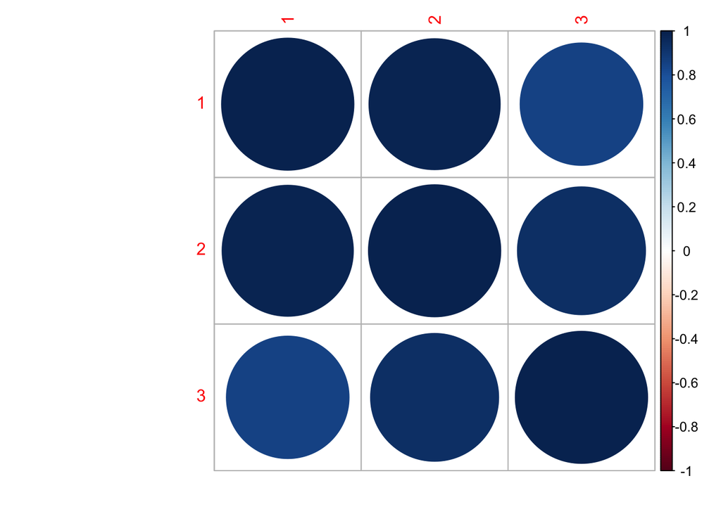

```r
require(corrplot)
Qmat <- coef(fit3, type="matrix")$Q
M <- cov2cor(Qmat)
corrplot(M)
```

The states for this model are similar but have different trends.

```
## plot type = "xtT" Estimated states
```

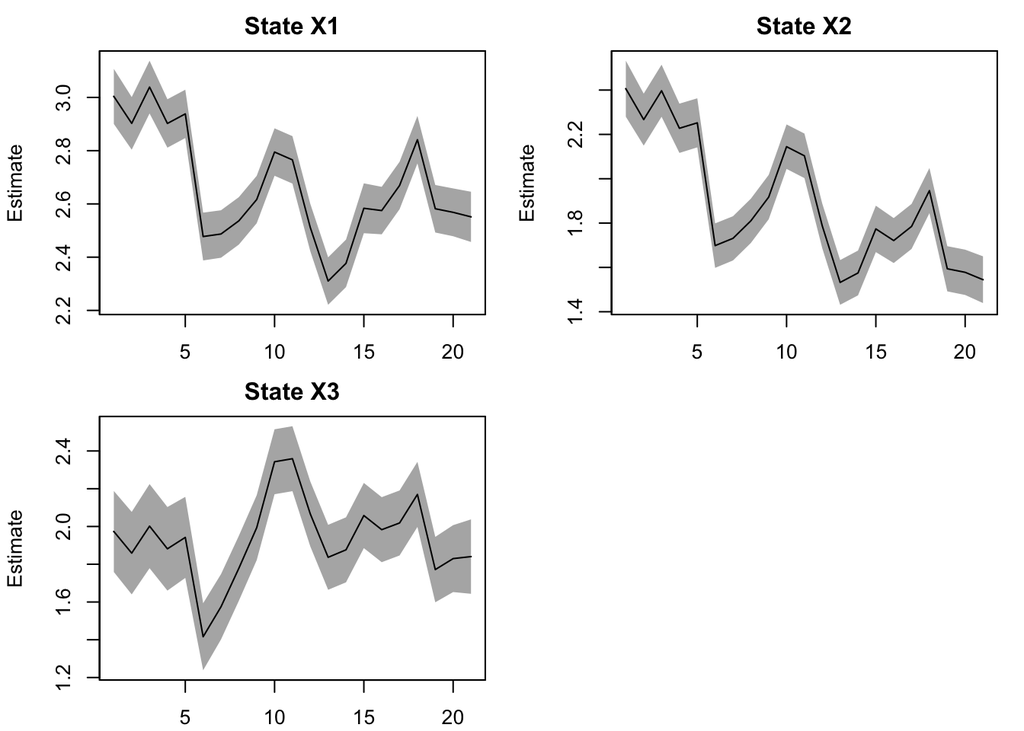

```r
plot(fit3, plot.type="xtT")
```

5. What structure(s) did you assume for the $\mathbf{Q}$ matrix (process or state variance)? What does that imply about how the underlying NO$_2$ trends are related yearly? Your `MARSS()` model will look like so.

```
MARSS(datmat, model=list(R=..., Z=..., Q=...))
```

See comments above.

**Some ideas for OPTIONAL extra analyses**

- OPTIONAL. Go back to question 1 and the model with 1 state. Instead of assuming that all $y$ observe the same $x$, assume they can observed a ‘stretched’ $x$ so $y_{i,t} = z_i x_t + v_t$. Fit that model and look at the estimated $\mathbf{Z}$ matrix. What does it say? Is it more supported than a model without ‘stretching’?

  Note you will need to remove the mean from the data and set `A="zero"` to fit a model where you estimate $\mathbf{Z}$.

  ```
  newdat <- zscore(datmat, mean.only=TRUE)
  MARSS(newdat, model=list(R=.., Z=..., A="zero"))
  ```

The idea here is that we have the $x$ scale 1 to 1 to one $y$ (let’s say the first) and then use $z_i$ to scale the $x$ for the other $y$. This gets us $y_{i,t} = z_i x_t + v_{i,t}$.

The $\mathbf{Z}$ matrix for this model is an 11-row, 1-column matrix as before, but now each entry is $z$, not 1, to model the “stretching”. Note you could have also fit this by estimating $z_1$. It would work but it’s just that one of the $z$ is underdetermined and should be fixed.

$$\mathbf{Z} = \begin{bmatrix}
1 \\
z_3 \\
z_4 \\
z_5 \\
z_6 \\
z_7 \\
z_8 \\
z_9 \\
z_{10} \\
z_{11} \\
z_{12} \\
\end{bmatrix}$$

```r
Z2 <- matrix(list(1),11,1)
Z2[2:11,] <- paste0("z",3:12)
```

```r
mod.list4 <- list(Z = Z2,
                  R = "diagonal and unequal",
                  A = "zero")
datmat2 <- zscore(datmat, mean.only=TRUE)
fit4 <- MARSS(datmat2, model=mod.list4)
```

```r
mod.list5 <- list(Z = matrix(1,11,1),
                  R = "diagonal and unequal",
                  A = "zero")
fit5 <- MARSS(datmat2, model=mod.list4)
```

- OPTIONAL. Try fitting with lm(), a Arima() or another linear non-state-space model with a polynomial trend in year to try to capture the time-varying trend. How are the results similar or different? You might be able to just include a year effect as a factor too.

Instead of this, I just took the mean of the data and smoothed the data. It looks fairly similar to the state for fit1. The offset is because the MARSS model makes $x$ match $y_1$.

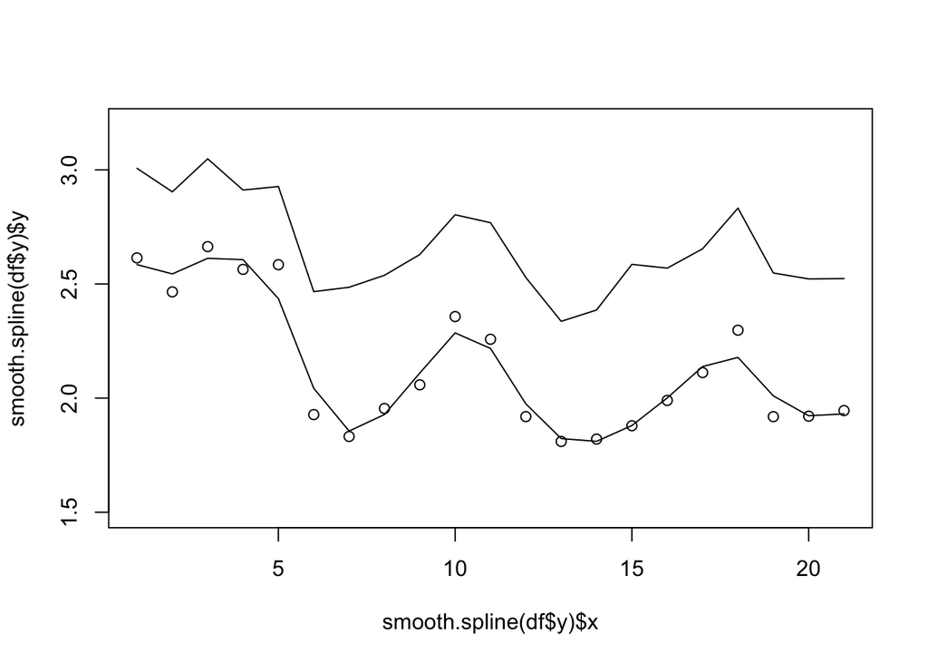

```r
df <- data.frame(y = apply(datmat, 2, mean, na.rm=TRUE),
                 t = 1:21)
plot(smooth.spline(df$y), type="l", ylim=c(1.5,3.2))
lines(fit1$states[1,])
points(df$y)
```

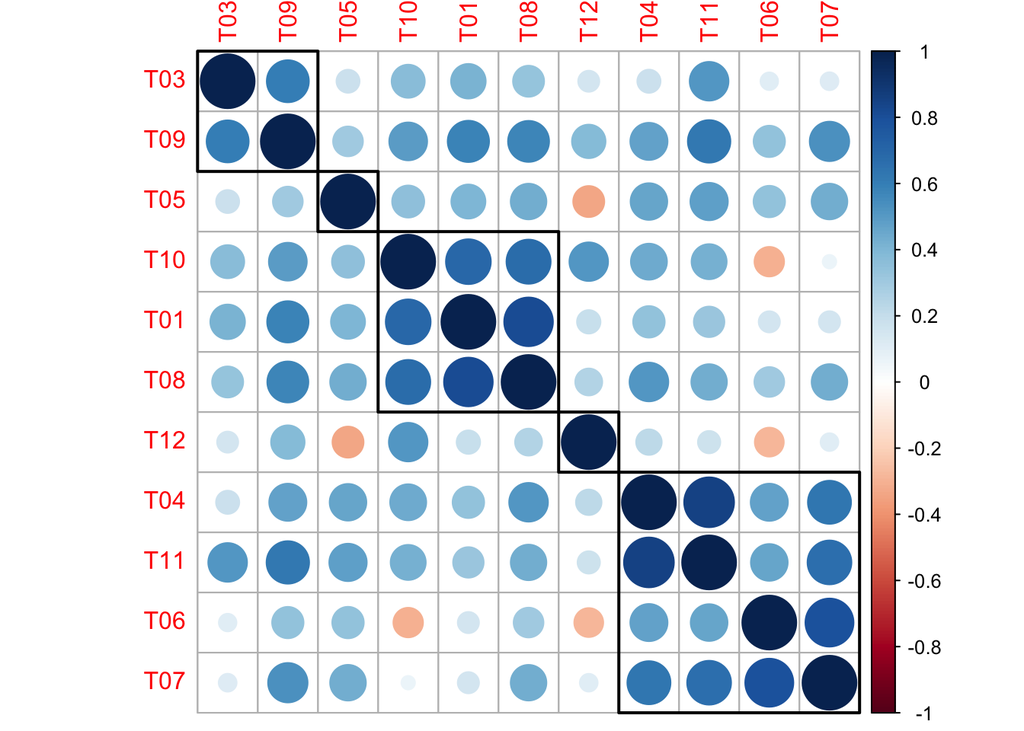

```r
M <- cor(t(datmat), use="complete.obs")
corrplot::corrplot(M, order = "hclust", addrect = 5)
```

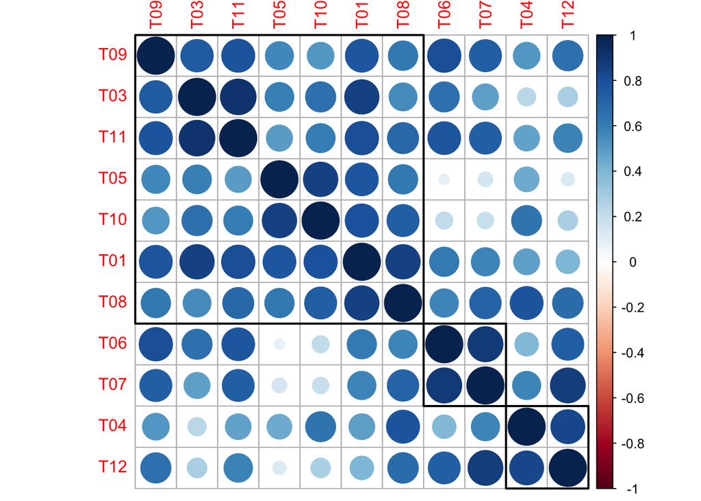

```r
fit <- MARSS(datmat, model=list(R="diagonal and unequal", Q="unconstrained"))
Qmat <- coef(fit, type="matrix")$Q
rownames(Qmat) <- colnames(Qmat) <- rownames(datmat)
M <- cov2cor(Qmat)
corrplot(M, order = "hclust", addrect = 3)
```

## Part 2

Data for part 2 is `datmat2` below. What the code is doing: take the ECNNO2 monthly data, get just tube E1, make a column with Year-Mon, remove the unneeded columns, pivot wider, make into a matrix.

```r
datwide <- ECNNO2 %>%
  subset(TubeID=="E1") %>%
  mutate(Year.Mon=paste(Year, Month, sep="-")) %>%
  select(-Year, -Month, -TubeID, -Date) %>%
  pivot_wider(
    names_from = Year.Mon,
    values_from = Value
  )
# make into a matrix
datmat2 <- as.matrix(datwide[,-1])
# deal with NaN
datmat2[is.na(datmat2)] <- NA
# log the data
datmat2[datmat2==0] <- NA
datmat2 <- log(datmat2)
rownames(datmat2) <- datwide$SiteCode
```

6. Repeat question 1 (one underlying NO$_2$ trend) for the monthly data. [Model seasonality as a Fourier series](https://atsa-es.github.io/atsa-labs/sec-msscov-season.html) where the seasonality is in the process errors (the $x$).

Create covariate

```r
TT <- dim(datmat2)[2] # time steps
period <- 12
cos.t <- cos(2 * pi * seq(TT)/period)
sin.t <- sin(2 * pi * seq(TT)/period)
covariate <- rbind(cos.t, sin.t)
```

Fit model

```r
fit.seas1 <- MARSS(datmat2, model=list(Z = matrix(1, 11, 1),
                                R = "diagonal and unequal",
                                C = "unconstrained",
                                c = covariate))
```

Let’s look at the state. It is cyclic as we expect.

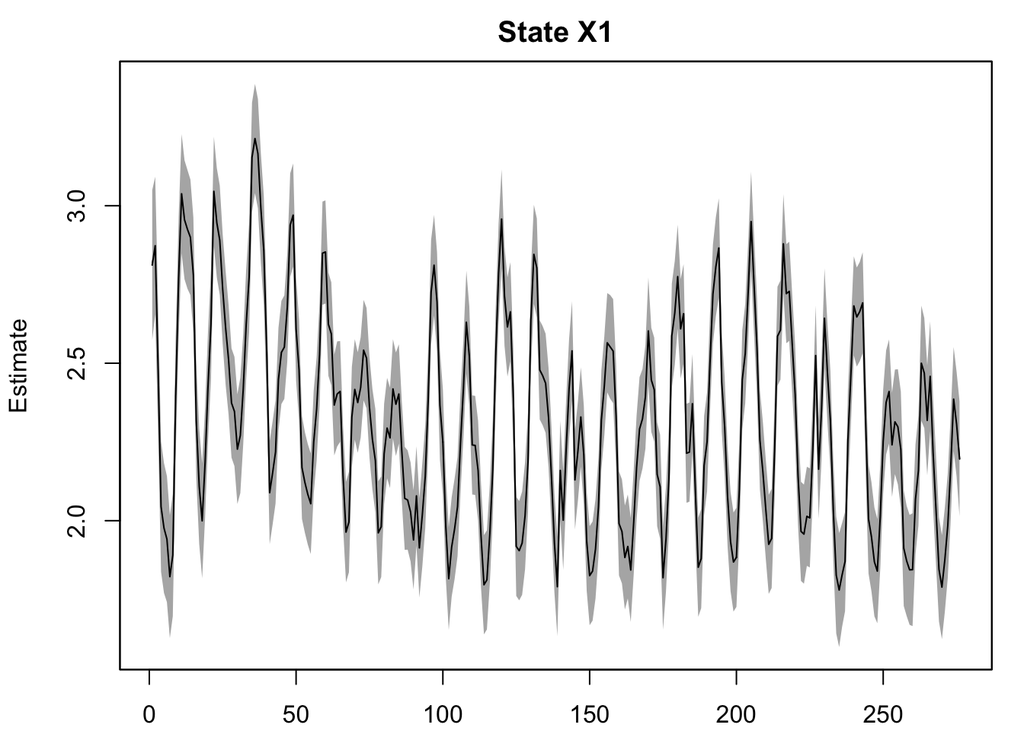

```
## plot type = "xtT" Estimated states
```

```r
plot(fit.seas1, plot.type="xtT")
```

### Plot ACFs

[figure not shown]

```r
par(mfrow = c(3,4), mar=c(2,2,3,2))
sites <- rownames(datmat)
for(i in sites){
  tmp <- subset(resids, .rownames==i)$.resids
  acf(tmp, na.action=na.pass, main=i)
}
```

7. Fit the same model but where the seasonality is in the observation errors. Allow the seasonality to be different for each site.
8. Which one fits better (based on AICc)? How do these models treat seasonality differently?

**Ideas for OPTIONAL extra analyses**

- OPTIONAL. Use the model from question 8. Adapt the code for [Figure 8.2](https://atsa-es.github.io/atsa-labs/sec-msscov-season.html) in the lab manual to look at the seasonal effects for each site. Where is the seasonality the strongest (biggest difference between winter and summer)?
- OPTIONAL. Use the model from question 8. Structure your $\mathbf{D}$ matrix into the 3 regions so that each region has the same seasonal effect (same $\mathbf{D}$ values).
- OPTIONAL. Try some other approaches for modeling seaonsality such as monthly factors or polynomials. Any difference in the seasonal pattern?